# Basic Goodness-of-fit Diagnostic Plots

Certara PMxO R Tools Workstream

17-Nov-2020

# Setup

Before starting, load the `ggplot2` and `ggcertara` packages, and set the default `ggplot` theme to `theme_certara()`:

```r
suppressPackageStartupMessages({
  library(ggplot2)
  library(ggcertara)
  library(kableExtra) #used for the vignette not for ggcertara demonstration
})
theme_set(theme_certara())
```

# Overview

The `ggcertara` package and `theme_certara` theme are meant to provide a standardized look to typical `gof` plots employed by pharmacometricians. The syntax is based on `ggplot2`. The `ggcertara` also utilizes the `patchwork` package and syntax. These will be touched upon later in this vignette.

# Data:

## Data Expectations

The `gof()` function uses standard column names in lower case. The following column names are recognized by the functions in this package:

- time: Time (e.g., time since first dose)
- tad: Time after dose
- dv: Dependent variable
- pred: Population prediction
- ipred: Individual prediction
- cwres: Conditional weighted residual
- iwres: Individual weighted residual

Not all of these need to be present, only those that are needed for the disired plots (for instance, if no plots involving `iwres` are requested, then it does not need to be present). The column names must be in lower case.

## Reading:

The `gof_read_data()` function simplifies the data loading process by:

1. loading the data
2. converting all names to lower case
3. checking for the presence of an `mdv` column and, if present, filtering the rows to keep only those with `mdv = 0`

For this vignette we will be using some sample data that is provided with the package. The data is contained in a file named `nmtable.csv`, that was actually generated by NONMEM using a `$TABLE` statement (i.e., `$TABLE FILE=nmtable.csv FORMAT=,1PE15.8 ...`). It’s contents look like this:

| ID | TIME | DV | PRED | IPRED | RES | WRES | CWRES | CIWRES | IRES | IWRES | MDV | EVID | TAD | CL | V | KA | ETA1 | ETA2 | ETA3 |
| --- | --- | --- | --- | --- | --- | --- | --- | --- | --- | --- | --- | --- | --- | --- | --- | --- | --- | --- | --- |
| 1 | 0.0000000 | 0.00000 | 0.00000 | 0.00000 | 0.0000000 | 0.0000000 | 0.0000000 | 0.0000000 | 0.0000000 | 0.0000000 | 1 | 1 | 0.0000000 | 3.311365 | 10.26801 | 2.860697 | -0.144312 | -0.1010664 | 0.0747987 |
| 1 | 0.1107401 | 16.84466 | 14.39002 | 16.98482 | 2.4546404 | 0.0413047 | 0.0306011 | -0.1043802 | -0.1401575 | -0.1038259 | 0 | 0 | 0.1107401 | 3.311365 | 10.26801 | 2.860697 | -0.144312 | -0.1010664 | 0.0747987 |
| 1 | 0.2493163 | 33.22216 | 26.62746 | 31.08233 | 6.5946926 | 1.2657456 | 1.1250718 | 0.8657021 | 2.1398227 | 0.8661927 | 0 | 0 | 0.2493163 | 3.311365 | 10.26801 | 2.860697 | -0.144312 | -0.1010664 | 0.0747987 |
| 1 | 0.4983335 | 43.48446 | 38.21232 | 43.90453 | 5.2721396 | 0.2099566 | 0.1983909 | -0.1206951 | -0.4200702 | -0.1203824 | 0 | 0 | 0.4983335 | 3.311365 | 10.26801 | 2.860697 | -0.144312 | -0.1010664 | 0.0747987 |
| 1 | 0.8483932 | 48.27355 | 42.64485 | 48.29827 | 5.6286966 | 0.3379642 | 0.3135719 | -0.0066225 | -0.0247160 | -0.0064387 | 0 | 0 | 0.8483932 | 3.311365 | 10.26801 | 2.860697 | -0.144312 | -0.1010664 | 0.0747987 |
| 1 | 2.1580771 | 32.07656 | 31.68700 | 35.66761 | 0.3895546 | -1.0379582 | -0.9256054 | -1.2668550 | -3.5910498 | -1.2667701 | 0 | 0 | 2.1580771 | 3.311365 | 10.26801 | 2.860697 | -0.144312 | -0.1010664 | 0.0747987 |

In a normal project workflow, the location of the appropriate file would be clear. For the vignette, the file can be located as follows:

```r
file <- system.file(package="ggcertara", "sample-data/nmtable.csv")
```

Now we load the file:

```r
dat <- gof_read_data(file)
```

Examining the data, we can see that the names are lower case and the rows have been filtered such that `mdv = 0`:

```r
head(dat)
```

```
#>   id      time       dv     pred    ipred       res        wres      cwres       ciwres        ires        iwres mdv evid       tad
#> 2  1 0.1107401 16.84466 14.39002 16.98482 2.4546404  0.04130471  0.0306011 -0.104380162 -0.14015753 -0.103825922   0    0 0.1107401
#> 3  1 0.2493163 33.22216 26.62746 31.08233 6.5946926  1.26574562  1.1250718  0.865702143  2.13982267  0.866192653   0    0 0.2493163
#> 4  1 0.4983335 43.48446 38.21232 43.90453 5.2721396  0.20995661  0.1983909 -0.120695079 -0.42007023 -0.120382378   0    0 0.4983335
#> 5  1 0.8483932 48.27355 42.64485 48.29827 5.6286966  0.33796419  0.3135719 -0.006622542 -0.02471603 -0.006438689   0    0 0.8483932
#> 6  1 2.1580771 32.07656 31.68700 35.66761 0.3895546 -1.03795820 -0.9256054 -1.266855000 -3.59104976 -1.266770110   0    0 2.1580771
#> 7  1 3.9157063 22.78889 17.64876 20.31905 5.1401243  2.03836621  1.8503260  1.529135290  2.46983532  1.529378070   0    0 3.9157063
#>         cl        v       ka      eta1       eta2       eta3
#> 2 3.311365 10.26801 2.860697 -0.144312 -0.1010664 0.07479871
#> 3 3.311365 10.26801 2.860697 -0.144312 -0.1010664 0.07479871
#> 4 3.311365 10.26801 2.860697 -0.144312 -0.1010664 0.07479871
#> 5 3.311365 10.26801 2.860697 -0.144312 -0.1010664 0.07479871
#> 6 3.311365 10.26801 2.860697 -0.144312 -0.1010664 0.07479871
#> 7 3.311365 10.26801 2.860697 -0.144312 -0.1010664 0.07479871
```

```r
table(dat$mdv)
```

```
#>
#>   0
#> 831
```

# Basic usage

The basic functionality is accessed through the `gof()` function:

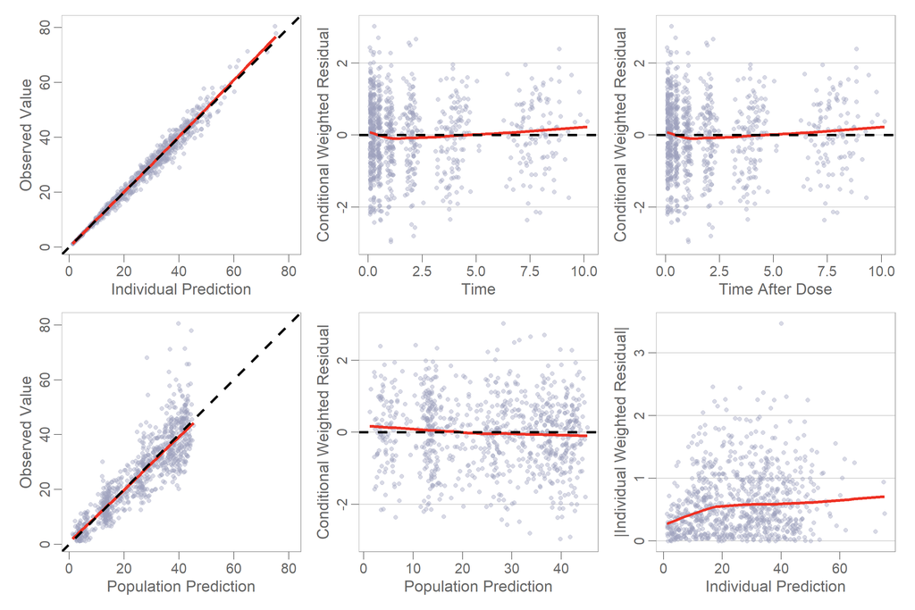

```r
gof(dat) #Note: output aspect ratio is set to 3:2, in this case width=9, height=6
```

By default, the `gof()` function produces a figure with 6 panels arranged in a 2-by-3 grid.

| Column_1 | Column_2 | Column_3 |
| --- | --- | --- |
| DV vs. IPRED | CWRES vs. TIME | CWRES vs. TAD |
| DV vs. PRED | CWRES vs. PRED | \|IWRES\| vs. IPRED |

Note that all axes are nicely labelled (though they lack units at this point). With this simple function call, we have produced a report ready figure!

# Customizing the output

## Selecting panels

The `gof()` function can easily produce a variety of panels which can be referenced as either numbered panels, named functions, or as strings.

| Number | Function | Name | Description |
| --- | --- | --- | --- |
| 1 | gof_cwres_histogram() | cwres_histogram | Histogram of CWRES |
| 2 | gof_cwres_qqplot() | cwres_qqplot | QQ-plot of CWRES |
| 3 | gof_dv_vs_ipred() | dv_vs_ipred | DV vs. IPRED |
| 4 | gof_dv_vs_pred() | dv_vs_pred | DV vs. PRED |
| 5 | gof_cwres_vs_pred() | cwres_vs_pred | CWRES vs. PRED |
| 6 | gof_cwres_vs_time() | cwres_vs_time | CWRES vs. TIME |
| 7 | gof_cwres_vs_tad() | cwres_vs_tad | CWRES vs. TAD |
| 8 | gof_absiwres_vs_ipred() | absiwres_vs_ipred | \|IWRES\| vs. IPRED |
| 9 | gof_absiwres_vs_time() | absiwres_vs_time | \|IWRES\| vs. TIME |
| 10 | gof_absiwres_vs_tad() | absiwres_vs_tad | \|IWRES\| vs. TAD |
| 11, -3 | gof_dv_vs_ipred(log_xy=T) | dv_vs_ipred_log | DV vs. IPRED log scale |
| 12, -4 | gof_dv_vs_pred(log_xy=T) | dv_vs_pred_log | DV vs. PRED log scale |
| 13, -5 | gof_cwres_vs_pred(log_x=T) | cwres_vs_pred_log | CWRES vs. PRED log scale |
| 14, -6 | gof_cwres_vs_time(log_x=T) | cwres_vs_time_log | CWRES vs. TIME log scale |
| 15, -7 | gof_cwres_vs_tad(log_x=T) | cwres_vs_tad_log | CWRES vs. TAD log scale |
| 16, -8 | gof_absiwres_vs_ipred(log_x=T) | absiwres_vs_ipred_log | \|IWRES\| vs. IPRED log scale |
| 17, -9 | gof_absiwres_vs_time(log_x=T) | absiwres_vs_time_log | \|IWRES\| vs. TIME log scale |
| 18, -10 | gof_absiwres_vs_tad(log_x=T) | absiwres_vs_tad_log | \|IWRES\| vs. TAD log scale |

Note that the standard 6 plots in the `gof()` function correspond to the numbered panels 3, 6, 7, 4, 5, 8 from this list.

### Calling the `panels` option within `gof()`

Using the `panels` argument, select panels can be selected using either the respective panel numbers or names (as strings). For example, to prduce both a histogram and QQ-plot of CWRES, select panels 1 and 2 or callthem by name `cwres_histogram` and `cwres_qqplot`:

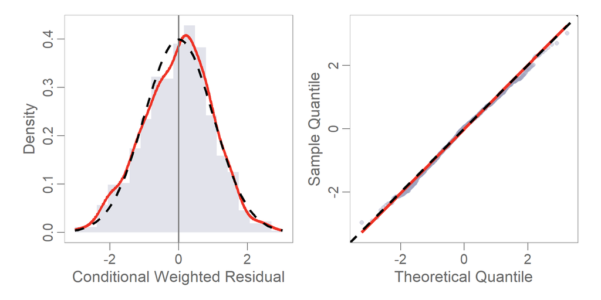

```r
gof(dat, panels=1:2)
```

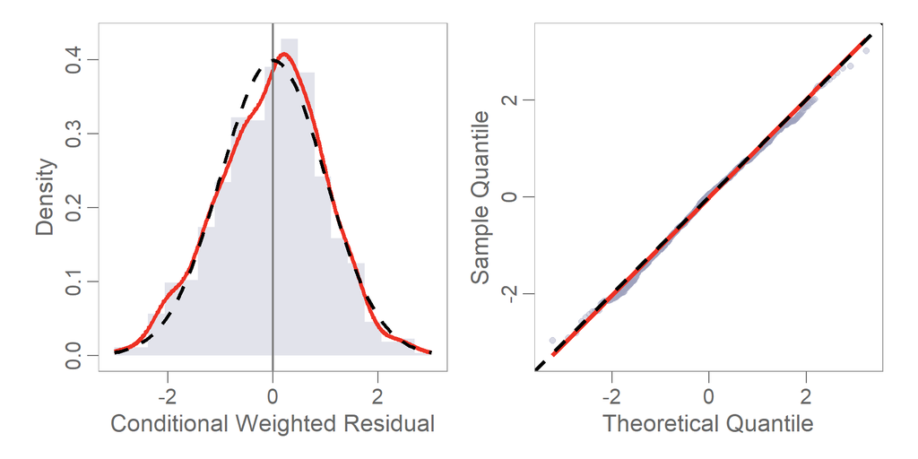

```r
gof(dat, panels=c('cwres_histogram', 'cwres_qqplot'))
```

For log-scale plots (panels 11-18 above), we can call their panel number or add a `-` to their linear scale counterpart. For example, to obtain a plot of DV vs. IPRED on log-log scale, we can set `panel=11` or `panel=-3`:

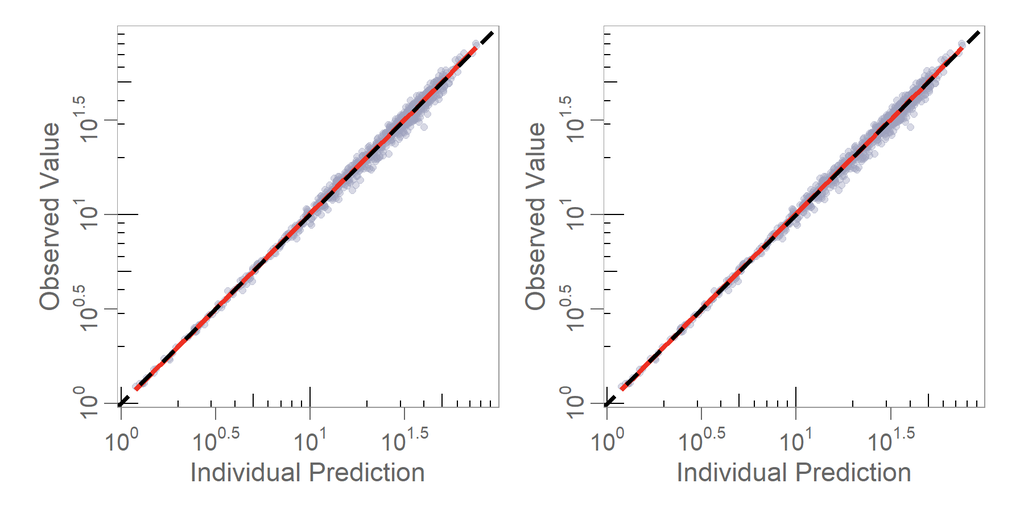

```r
gof(dat, panels=c(11,-3))
```

We can use the `layout` option to specify the number of rows and columns in a multi-panel output.

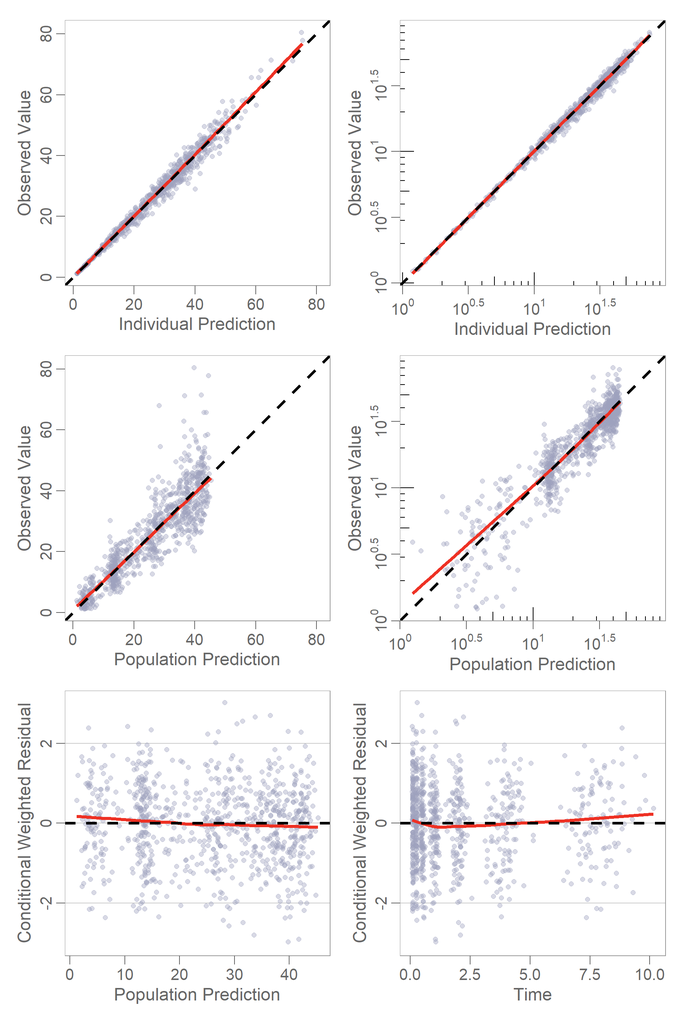

```r
gof(dat, panels=c(3, -3, 4, -4, 5, 6), layout = c(3, 2))
```

### Named function:

We can also call specific panels using the corresponding named function. Log variants of the plot can be obtained by specifying either `log_x=T` or `log_xy=T` depending on the function.

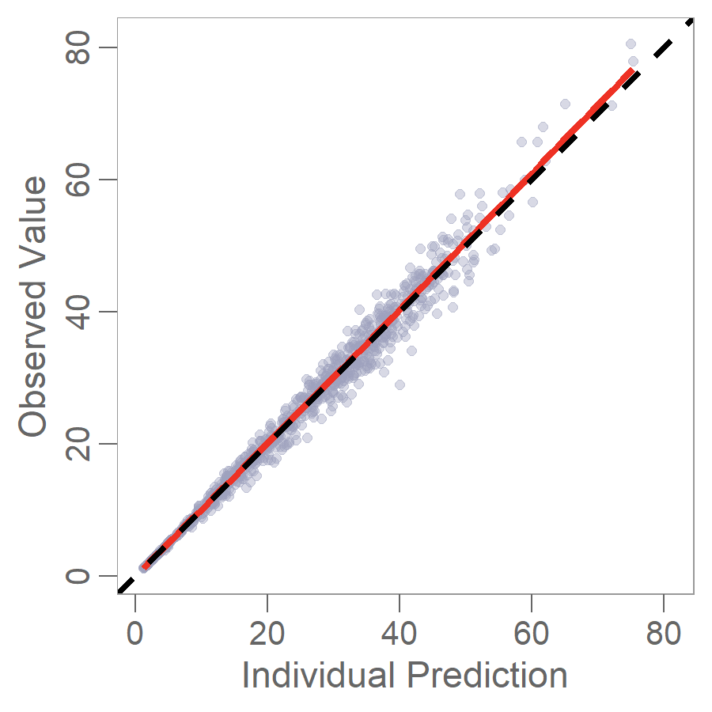

```r
gof_dv_vs_ipred(dat)
```

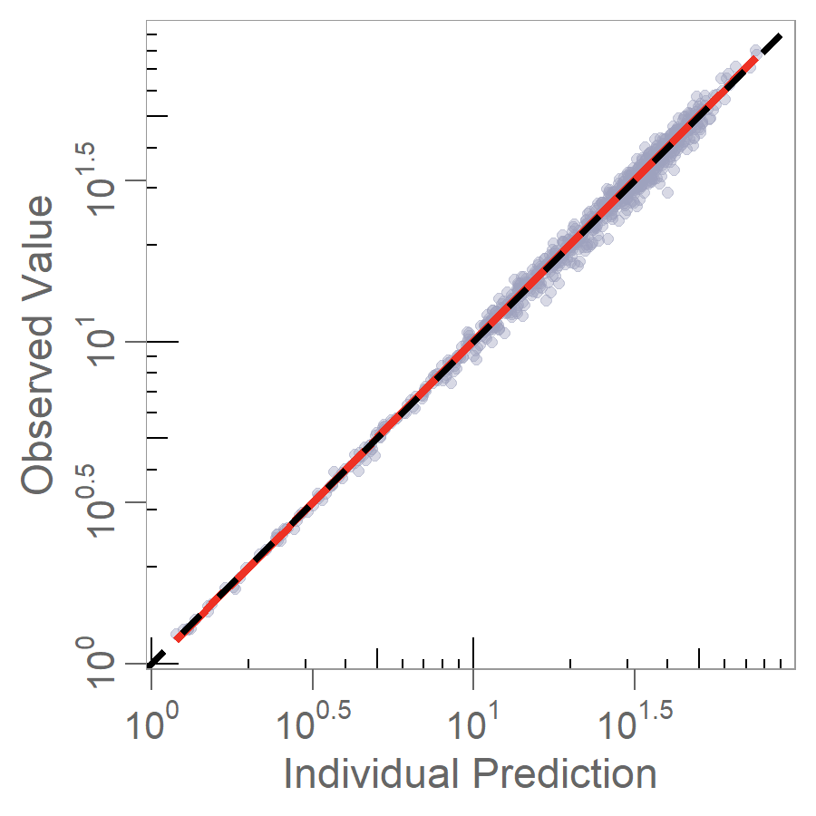

```r
gof_dv_vs_ipred(dat, log_xy=T)
```

### The `gof_list` object

Individual panels can also be with the `gof_list()` function. This returns a numbered list of the 6 standard panels by default, or all panels if `all=T` is specified:

```r
p <- gof_list(dat, all=T)
p
```

```
#> List of gof plots:
#>
#>   1. cwres_histogram
#>   2. cwres_qqplot
#>   3. dv_vs_ipred
#>   4. dv_vs_pred
#>   5. cwres_vs_pred
#>   6. cwres_vs_time
#>   7. cwres_vs_tad
#>   8. absiwres_vs_ipred
#>   9. absiwres_vs_time
#>   10. absiwres_vs_tad
#>   11. dv_vs_ipred_log
#>   12. dv_vs_pred_log
#>   13. cwres_vs_pred_log
#>   14. cwres_vs_time_log
#>   15. cwres_vs_tad_log
#>   16. absiwres_vs_ipred_log
#>   17. absiwres_vs_time_log
#>   18. absiwres_vs_tad_log
```

Individual panels can be extracted from the list:

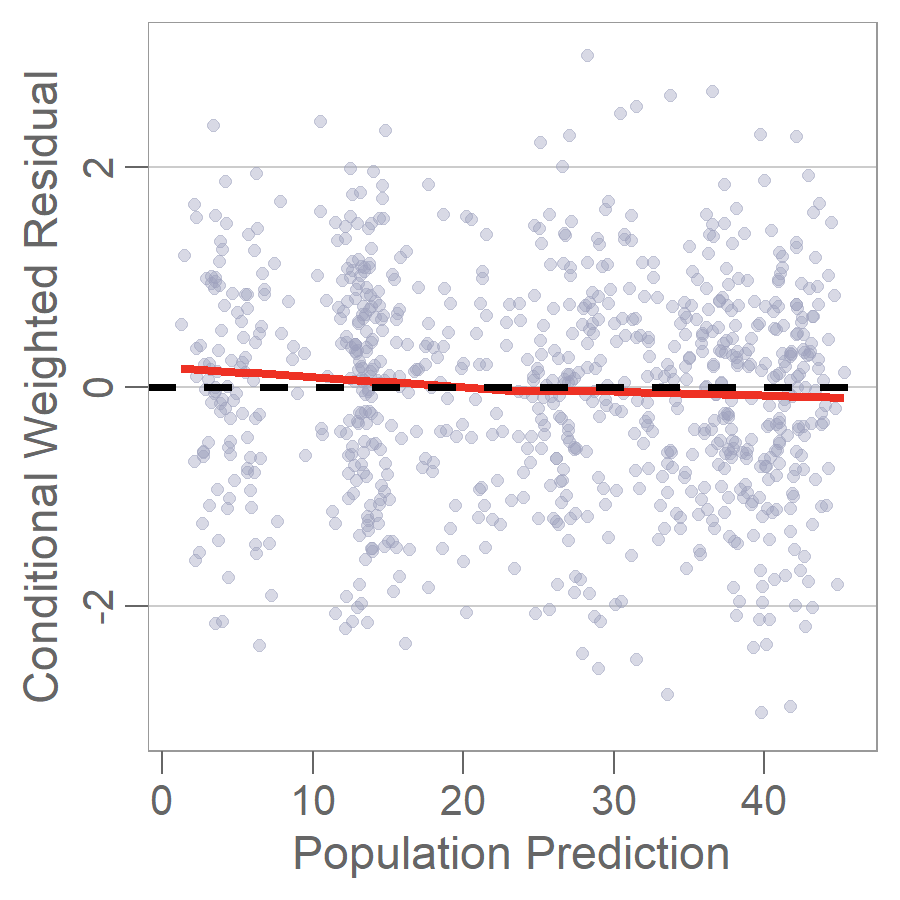

```r
p[[5]]
```

`gof_list` can also be used to build a new list of plots, by specifying `empty=T`:

```r
p <- gof_list(empty = T)
p[[1]] = gof_dv_vs_ipred(dat)
p[[2]] = gof_dv_vs_pred(dat)
```

A composite plot can be obtained from a list using the `gof_layout()` function:

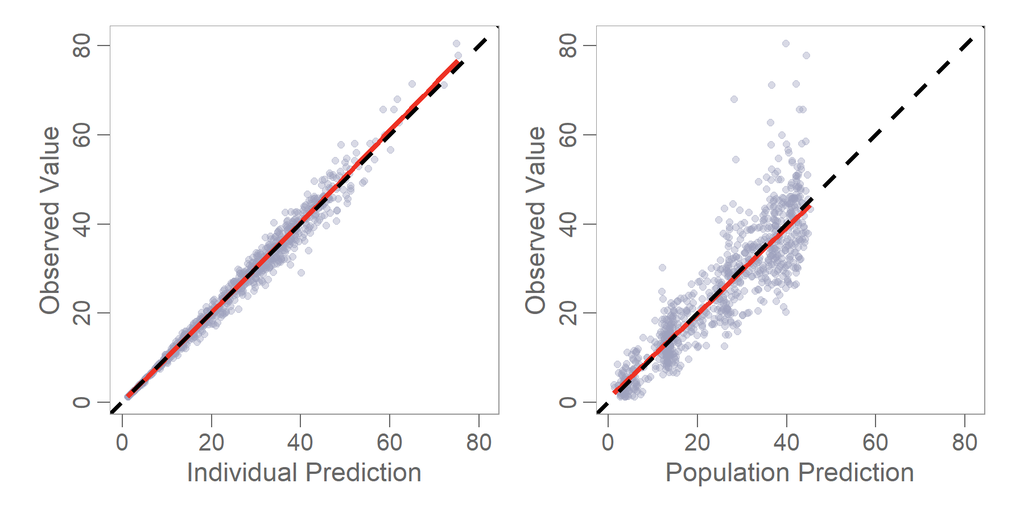

```r
gof_layout(p)
```

## Labels and units

There are several ways to customize the plot axis labels/units. When a recognized variable name is used in a plot (e.g. `ipred`, `cwres`, etc.), the functions will find a corresponding axis label in a list object which by default corresponds to a global option:

| Option | Default |
| --- | --- |
| gof.label.dv | Observed Value |
| gof.label.pred | Population Prediction |
| gof.label.ipred | Individual Prediction |
| gof.label.cwres | Conditional Weighted Residual |
| gof.label.iwres | Individual Weighted Residual |
| gof.label.time | Time |
| gof.label.tad | Time After Dose |
| gof.units.dv | NA |
| gof.units.time | NA |
| gof.units.tad | NA |

Every function has a `labels` argument to override the default, should it be necessary. Also note when updating labels/units, it is not required to specify all labels/units, only the labels/units that are being updated need be specified.

### Global label/units update

We can update labels and units at the global level by calling the desired option within the `options` function. Units for concentration (dv, pred, ipred), time, and tad can also be set using global options and will be appended to the label:

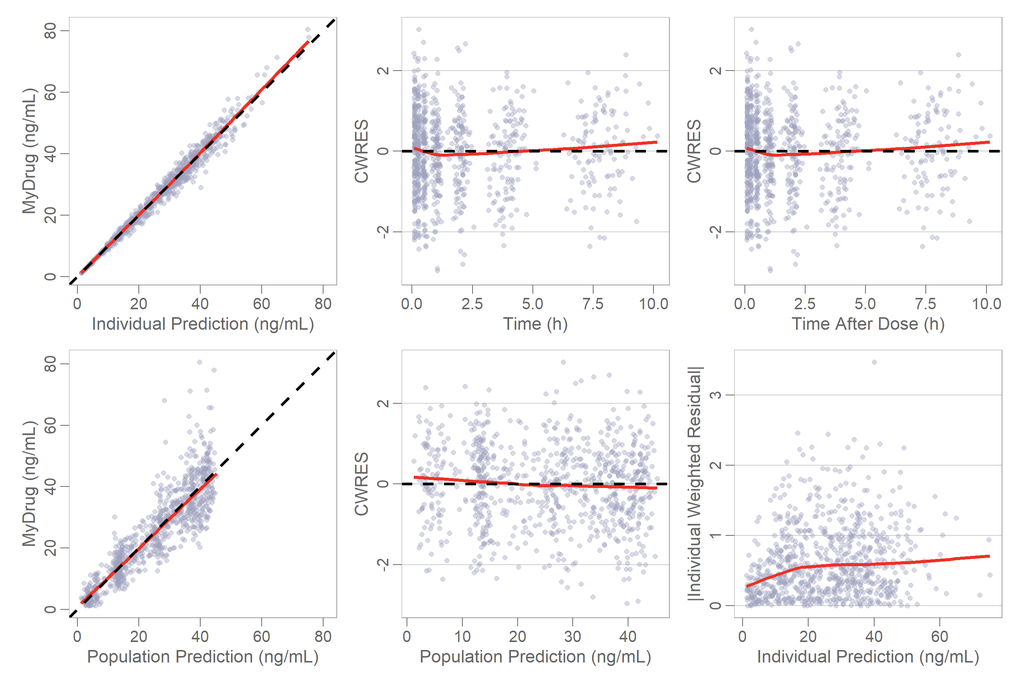

```r
options(gof.label.cwres = 'CWRES',
        gof.label.dv = 'MyDrug',
        gof.units.dv="ng/mL",
        gof.units.time="h",
        gof.units.tad="h")
gof(dat)
```

### Update labels for a single plot

We can update a default label for a single plot by calling the `label` option as follows.

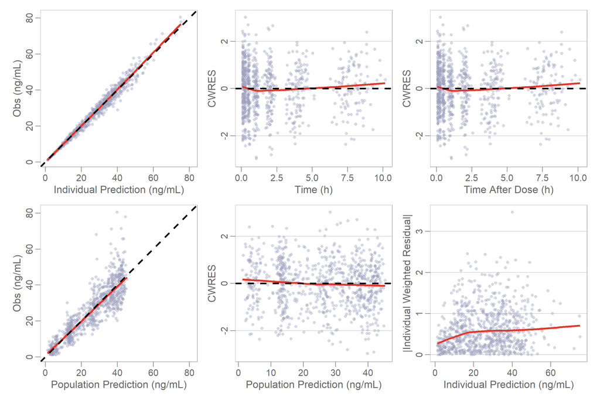

```r
gof(dat, labels = gof_labels(dv='Obs'))
```

Finally, the usual `labs()` function can be used to set or modify the labels of any plot. In this case, units do not get applied and must be explicitly included in the labels.

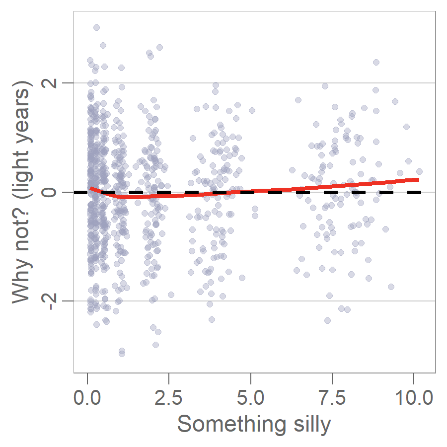

```r
gof(dat, 6) + labs(x="Something silly", y="Why not? (light years)")
```

Now let’s restore our defaults before moving on…

```r
# Restore defaults
options(gof.label.dv    = "Observed Value",
        gof.label.pred  = "Population Prediction",
        gof.label.ipred = "Individual Prediction",
        gof.label.cwres = "Conditional Weighted Residual",
        gof.label.iwres = "Individual Weighted Residual",
        gof.label.time  = "Time",
        gof.label.tad   = "Time After Dose",
        gof.units.dv=NA,
        gof.units.time=NA,
        gof.units.tad=NA
)
```

## Outliers

To highlight outliers using a special symbol (and color), you first define a column in the dataset which is a factor with 2 levels (be mindful of the labels, as these will appear in the legend and also note the use of unicode language for special symbols). The sample data comes from a simulation, and doesn’t have any outliers, but for demonstration purposes we will pretend that `|CWRES| > 2.5` is a criterion for defining outliers:

```r
dat$outlier <- factor(abs(dat$cwres) > 2.5, labels=c("|CWRES| \U{2264} 2.5", "|CWRES| > 2.5"))
```

Then, use the `highlight` option, like this:

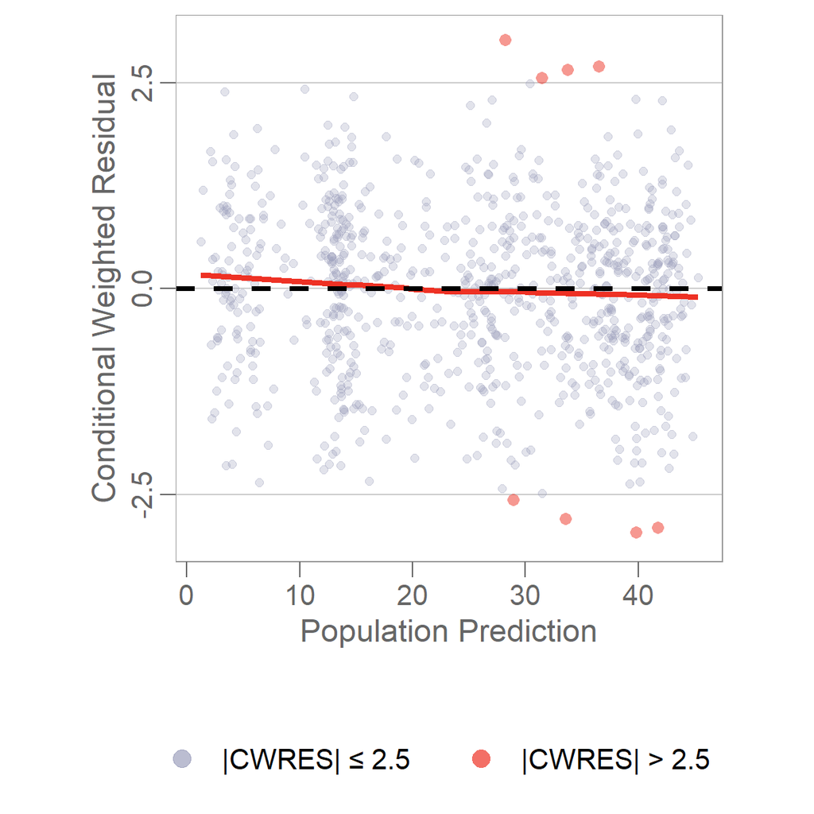

```r
gof_cwres_vs_pred(dat, highlight=outlier) +
  scale_y_continuous(breaks = c(-2.5,0,2.5))
```

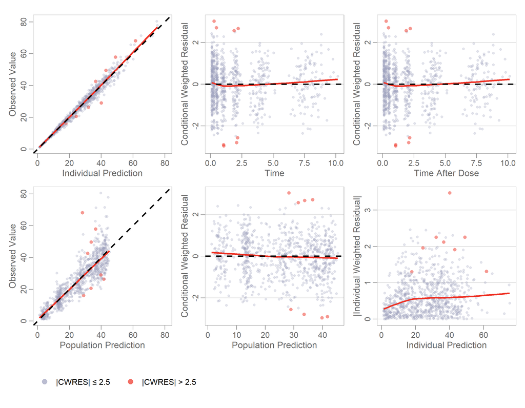

```r
gof(dat, highlight=outlier)
```

## Faceting

Faceting can be applied with `facet_wrap` or `facet_grid` as with any `ggplot` object. For this example, we will augment our data with some covariate information, specifically sex and study information. In the same folder as the dataset `nmtable.csv` is a file `pkpop.csv` that contains covariate information on PK population.

```r
file <- system.file(package="ggcertara", "sample-data/pkpop.csv")

pkpop <- read.csv(file)
head(pkpop)
```

```
#>   id sex age    wt study
#> 1  1   1  59  65.4     1
#> 2  2   0  37  64.3     1
#> 3  3   1  38  58.3     1
#> 4  4   0  31  73.3     1
#> 5  5   0  40 109.3     1
#> 6  6   1  79  56.5     1
```

Note that there is one row for each `id` in the dataset. We need to link this to our goodness-of-fit data by matching on the `id` column. There are many ways to do this (`merge()`, `left_join()`, …), but a simple way is to use the basic `match()` function:

```r
i <- match(dat$id, pkpop$id)
dat$sex   <- pkpop$sex[i]
dat$study <- pkpop$study[i]
```

We have now added sex and study to our dataset, but in order to get nice, informative labels, we should convert these to `factor`:

```r
dat$sex = factor(dat$sex, levels=0:1, labels=c('Female', 'Male'))
dat$study = factor(dat$study, levels=1:3, labels=c('Study A', 'Study B', 'Study C'))
```

Now, we can produce a plot of DV vs. IPRED faceted by sex as follows:

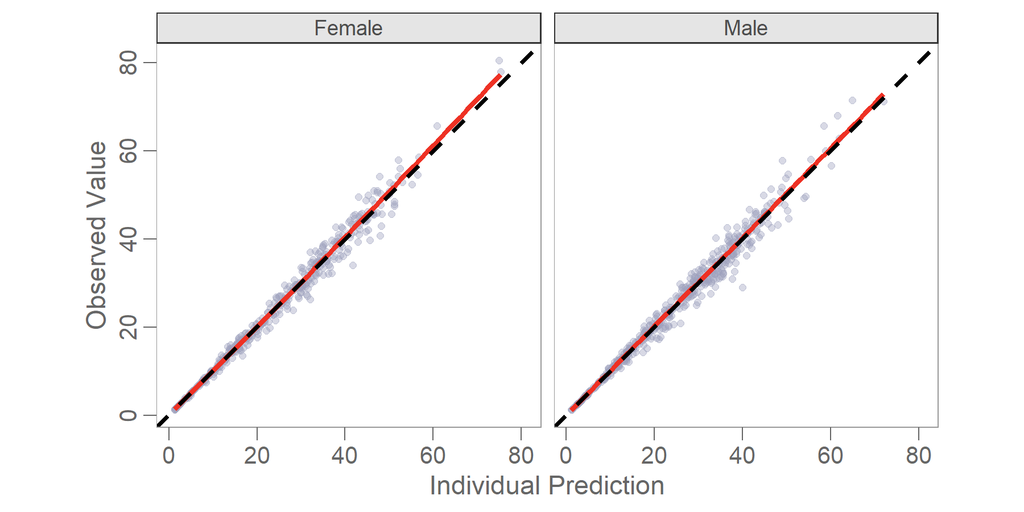

```r
gof(dat, panels = 3) + facet_wrap(~sex)
```

## Changing aesthetics (colors, etc.)

### Global changes

Changes that will affect all plots can be made with the `update_geom_defaults()` function. For example, to change the alpha level used for points in all panels:

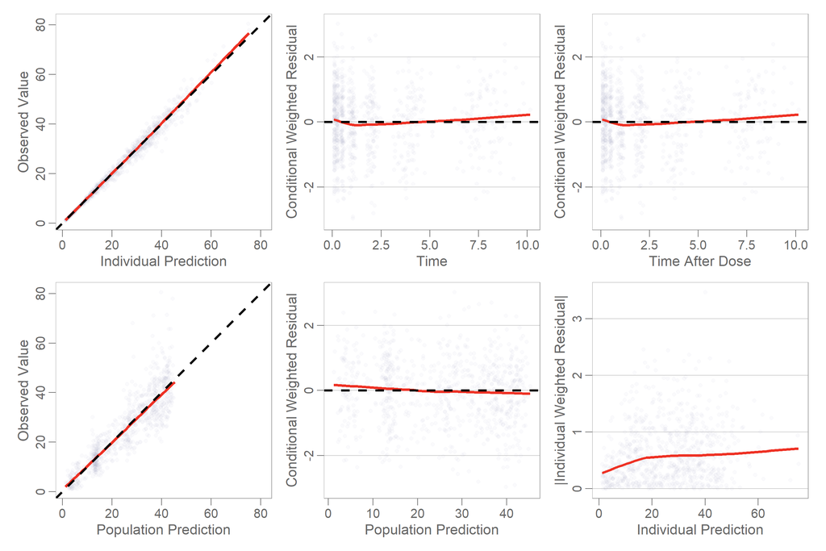

```r
update_geom_defaults("point_c", list(alpha=0.05)) # update the global options
gof(dat)
```

```r
update_geom_defaults("point_c", list(alpha=0.4)) # reset to default alpha
```

Note that a special custom geom, named `geom_point_c()`, is defined and used in this package, so that other `ggplot` code will not be affected.

### Changes to individual plots

For a single panel, you can just modify the `ggplot` object. For example, let’s change the color and symbol of points in a DV vs. PRED plot to be different by study (which we already added to our dataset earlier):

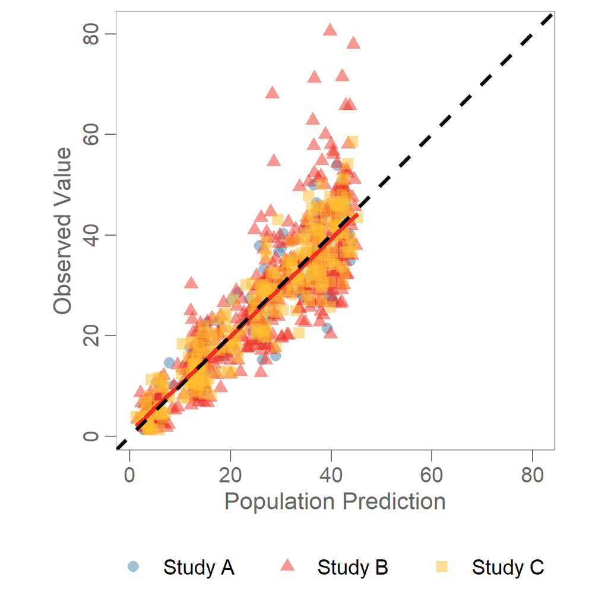

```r
update_geom_defaults("point_c", list(alpha=0.5, size=2.5)) # make points bigger and more opaque
gof(dat, panels=4) +
    aes(color=study, shape=study) +
    labs(color=NULL, shape=NULL) +
    scale_color_certara()
```

For a `patchwork` object (multiple panels), you can do the same thing by replacing the `+` operator with a `&`:

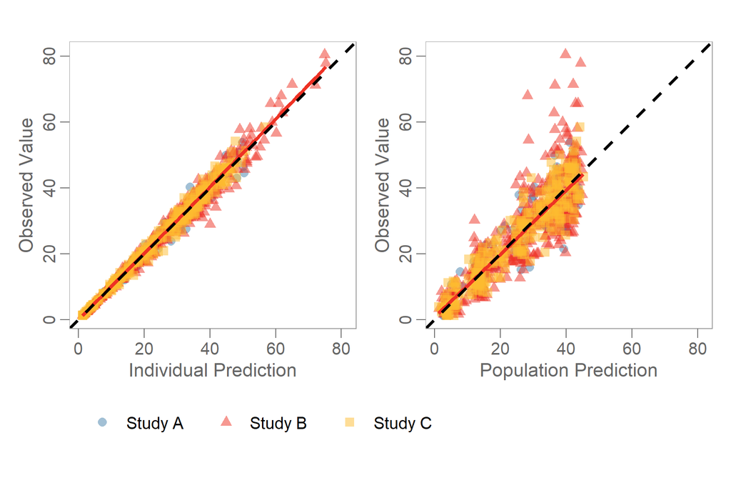

```r
gof(dat, panels=3:4) &
    aes(color=study, shape=study) &
    labs(color=NULL, shape=NULL) &
    scale_color_certara()
```

```r
update_geom_defaults("point_c", list(alpha=0.4, size=1.5)) # restore defaults
```

`patchwork` is smart enough to produce a single legend for both panels (note: the `theme_certara()` theme must be set globally, as it was at the beginning of this script, for this to display properly).

## Adding geoms and annotations

As with any ggplot object, geoms can be added. Remember to use the `&` operator instead of `+` when creating multiple panels (this notation comes from the `patchwork` package).

For examples, we can add a dashed line with corresponding label showing the LLOQ to our DV vs. IPRED and PRED plots as follows:

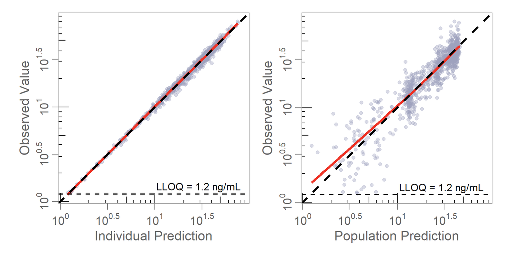

```r
 gof(dat, panels = -(3:4)) &
  geom_hline(yintercept=1.2, linetype="dashed") &
  geom_text(data=data.frame(x=Inf, y=1.2), aes(x=x, y=y),
    label="LLOQ = 1.2 ng/mL", hjust=1.1, vjust=-0.5, size=3)
```

As another example, we can add a blue linear regression line in addition to the red LOESS smooth to our panels:

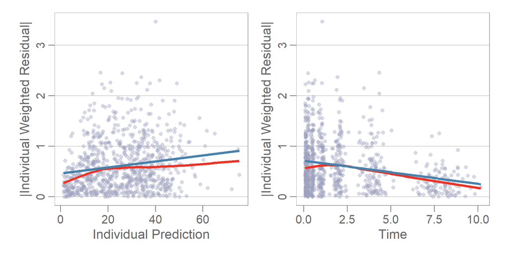

```r
gof(dat, panels=8:9) &
  geom_smooth(method="lm", color=certara_pal()[1], se=F, size=1)
```